[OHI-Northeast](http://www.ohi-northeast.org/) | [OHI Science](http://ohi-science.org) | [Citation policy](http://ohi-science.org/citation-policy/)

# OHINE: Species Pollution Resilience - Nonindigenous Aquatic Species USGS Data Prep

Compiled on Mon Oct 14 10:10:06 2019 by verstaen

# Summary

This script calculates the invasive species pressure by OHINE region.

# Data

**Nonindigenous Aquatic Species (NAS) USGS**

**Downloaded**: September, 2019

**Description**: This dataset has occurrence and precise location data of new nonindigenous species https://nas.er.usgs.gov/

**Time range**: 1700-2019

**Format**: csv file

# Methods

## Set up, libraries, load data

```r
knitr::opts_chunk$set(fig.width = 6, fig.height = 4, fig.path = 'figs/',
                      message = FALSE, warning = FALSE)

source('~/github/ne-prep/src/R/common.R')  ### an OHINE specific version of common.R
dir_git <- '~/github/ne-prep'
dir_anx <- file.path(dir_M, 'git-annex/neprep')

library(tidyverse)
library(dplyr)
```

```r
nas_raw <- read_csv(file.path(dir_anx, "_raw_data/NAS/NAS-Data-Download.csv"))
```

## Explore data for pressures

Exploring total number of occurrences that have become established for the species pollution pressure layer Now we want to see how many species are observed in a new area in each to quantify invasive species pressures

```r
nas_est <- nas_raw %>%
  select('Scientific Name', 'Country', 'State', 'Year', 'Status') %>%
  rename(sci_name = "Scientific Name") %>%
  filter(Status %in% c('established', 'locally established', 'eradicated','extirpated'),
         Country %in% 'United States of America',
         State %in% c("ME", "MA", "NY", "RI", "CT", "NH"),
         Year >= 1970 & Year <= 2018) %>%
  select(-Country) %>%
  unique() %>%
  mutate(counts = 1) %>%
  group_by(Year, State) %>%
  summarize(total_est = sum(counts)) %>%
  ungroup() %>%
  mutate(max_est = max(total_est),
         score = total_est/max_est)
```

Fish color palette for fun!

```r
library(fishualize)

cols = fish(6, option = "Thalassoma_bifasciatum")
```

Look at occurrences

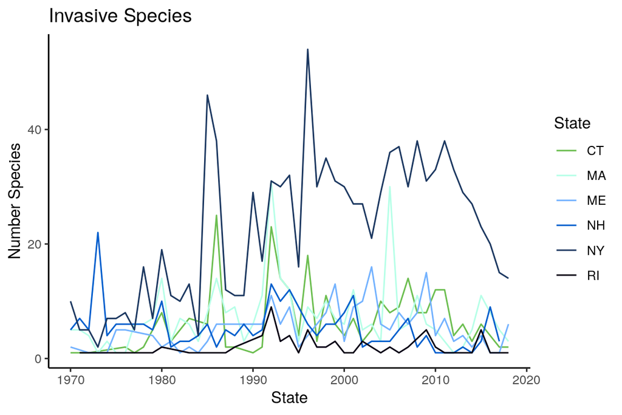

```r
est_gr <- ggplot(nas_est) +
  geom_line(aes(x= Year, y=total_est, color=State))+
  scale_color_fish_d(option = "Thalassoma_bifasciatum", direction = -1)+
  theme_classic() +
  labs(y = "Number Species", x = "State") +
  ggtitle("Invasive Species")

est_gr
```

```r
ggsave("figs/established_nas.jpg", width=7, height=5, dpi=300)
```

Look at scores

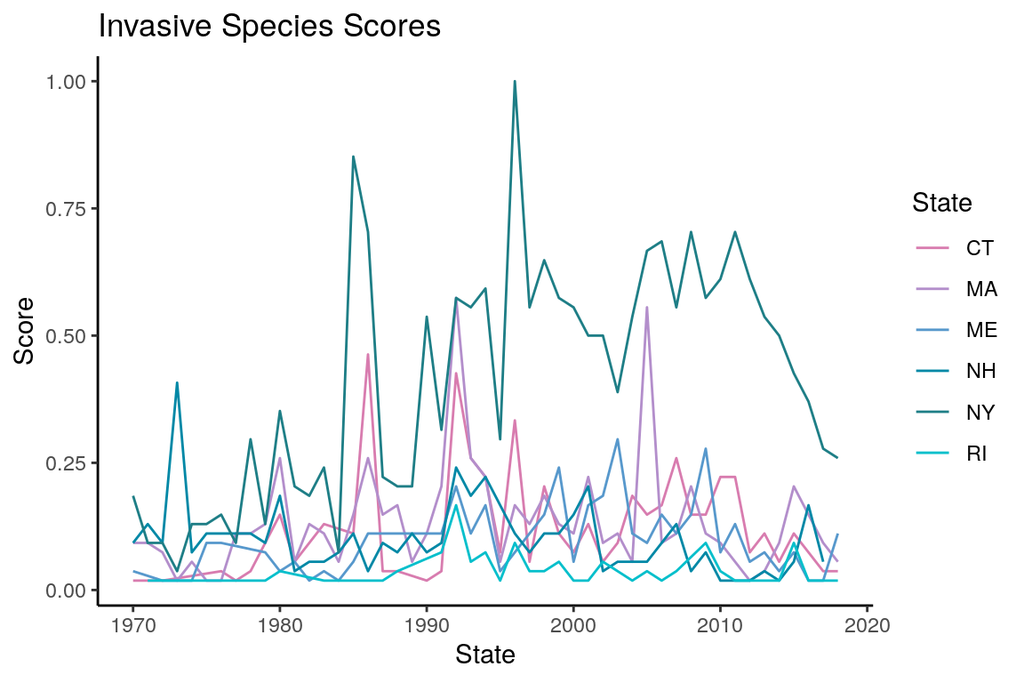

```r
scores <- ggplot(nas_est) +
  geom_line(aes(x= Year, y=score, color=State))+
  scale_color_fish_d(option = "Scarus_globiceps", direction = -1)+
  theme_classic() +
  labs(y = "Score", x = "State") +
  ggtitle("Invasive Species Scores")

scores
```

```r
ggsave("figs/scores.jpg", width=7, height=5, dpi=300)
```

Save a more simplified df for future score calculations

```r
invasive_prs_int <- nas_est %>%
  select(State, Year, score) %>%
  rename(year = Year) %>%
  filter(year >= 2005 & year <= 2017)
```

## Cleaning up the layer for scores

```r
nas_ri_miss <- tribble(
  ~year, ~rgn_name, ~rgn_id, ~score,
  2008, "Rhode Island", 11, 0,
  2011, "Rhode Island", 11, 0,
  2012, "Rhode Island", 11, 0,
  2013, "Rhode Island", 11, 0,
  ) %>%
  as.data.frame()
```

We also need to add on the offshore missing regions

```r
miss_rgns <- tribble(
  ~rgn_id, ~rgn_name,
  3, "Gulf of Maine",
  2, "Georges Bank",
  4, "Mid-Atlantic Bight",
  1, "Offshore")

miss_rgns <- miss_rgns %>%
  uncount(13, .id = "n", .remove = F) %>%
  mutate(year = ifelse(n == 1, 2005, n + 2004)) %>%
  select(-n) %>%
  mutate(score = NA) %>%
  unique()
```

```r
sp_alien <- invasive_prs_int %>%
  mutate(rgn_id1 = case_when(
    State == "ME" ~ "6",
    State == "NH" ~ "9",
    State == "MA" ~ "7",
    State == "RI" ~ "11",
    State == "CT" ~ "5",
    State == "NY" ~ "10"),
    rgn_id2 = case_when(
    State == "MA" ~ "8"
    )) %>%
  replace(., is.na(.), "0") %>%
  gather(rgn_id1, rgn_id2, key= "filler", value = "rgn_id") %>%
  filter(rgn_id != "0") %>%
  select(-filler, - State) %>%
  mutate(rgn_name = case_when(
    rgn_id == "6" ~ "Maine",
    rgn_id == "9" ~ "New Hampshire",
    rgn_id == "7" ~ "Massachusetts-North",
    rgn_id == "8" ~ "Massachusetts-South",
    rgn_id == "11" ~ "Rhode Island",
    rgn_id == "5" ~ "Connecticut",
    rgn_id == "10" ~ "New York")) %>%
  rbind(miss_rgns) %>%
  rbind(nas_ri_miss)
```

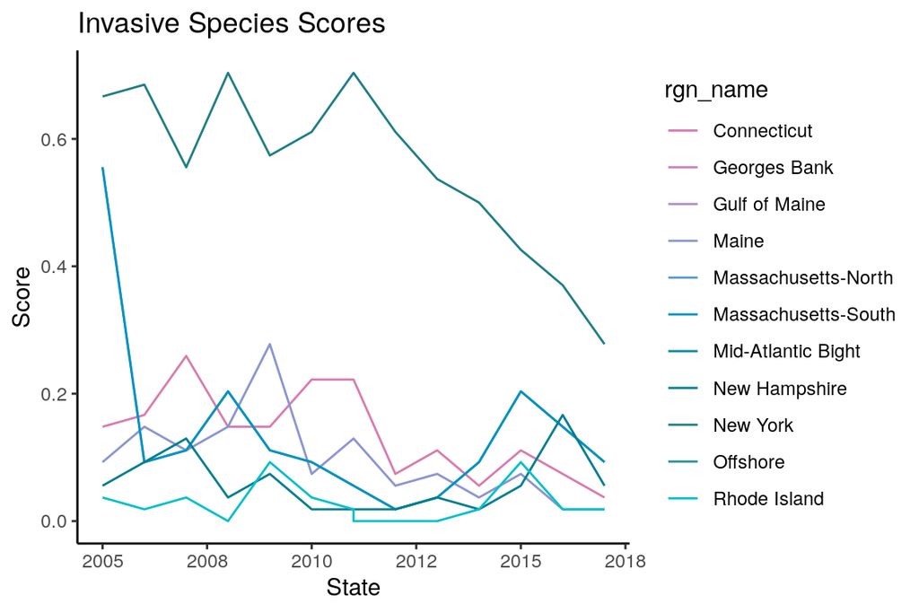

```r
scores <- ggplot(sp_alien) +
  geom_line(aes(x= year, y=score, color=rgn_name))+
  scale_color_fish_d(option = "Scarus_globiceps", direction = -1)+
  theme_classic() +
  labs(y = "Score", x = "State") +
  ggtitle("Invasive Species Scores")

scores
```

```r
ggsave("figs/sp_alien_scores.jpg", width=7, height=5, dpi=300)
```

Write as a pressure layer to ne-scores

```r
write.csv(sp_alien, file.path(dir_calc, "layers/sp_alien.csv"))
```